# Презентация по лабораторной работе №4

Основы информационной безопасности

Мажитов М. А.

Российский университет дружбы народов, Москва, Россия

28 сентября 2024

## Докладчик

- Мажитов Магомед Асхабович
- студент группы НКНбд-01-21
- Российский университет дружбы народов

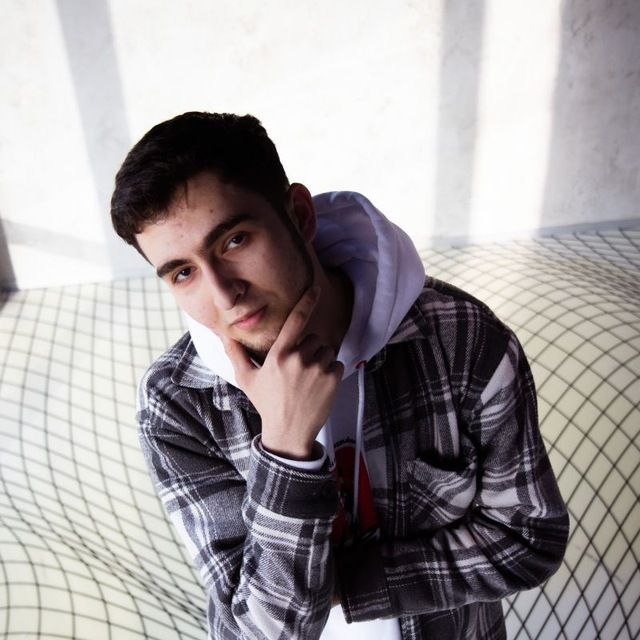

## Цель

Получение практических навыков работы в консоли с расширенными атрибутами файлов.

## Выполнение лабораторной работы.

От имени пользователя guest определил расширенные атрибуты файла *file1*.

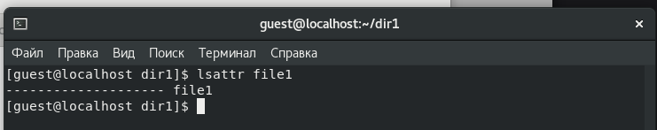

Атрибуты файла

Установил командой *chmod 600 file1* на файл *file1* права, разрешающие чтение и запись для владельца файла. Далее попробовал установить на файл *file1* расширенный атрибут *a* от имени пользователя *guest*.

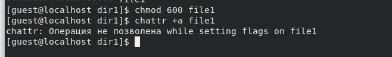

Изменение прав и попытка добавить расширенный атрибут

Открываю новую вкладку терминала и захожу с правами администратора. Пробую установить на файл *file1* расширенный атрибут *a*.

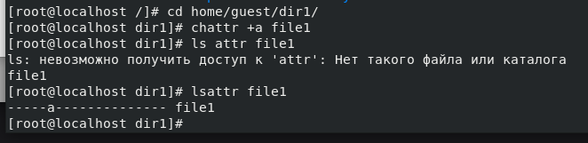

Добавление расширенного атрибута

От пользователя *guest* проверяю правильность установления атрибута.

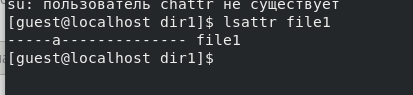

Расширенные атрибуты file1

Выполнил дозапись в файл *file1* слова *test*.

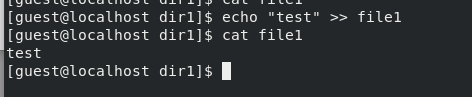

Дозапись

Попробовал стереть имеющуюся в нём информацию, переименовать файл, а также изменить права доступа к файлу.

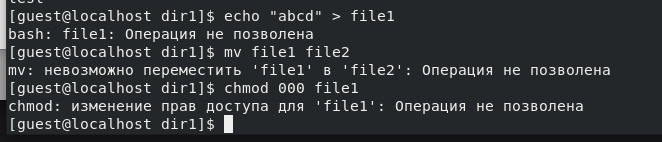

Попытка различных манипуляций с файлом

Как мы видим по скриншоту, попытки не увенчались успехом.

Снял расширенный атрибут *a* с файла *file1* от имени суперпользователя.

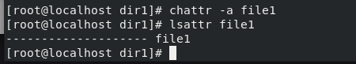

РСнятие расширенного атрибута

Попробовал повторить операции из пункта **6**.

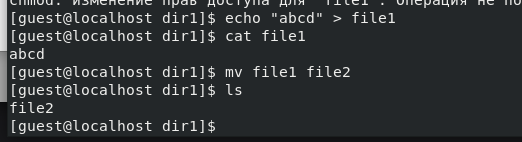

Попытка различных манипуляций с файлом

С измененными расширенными атрибутами все операции выполнились успешно.

Повторил пункты **3-6** по шагам, заменив атрибут «a» атрибутом «i».

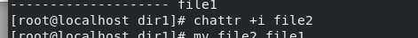

Добавление расширенного атрибута

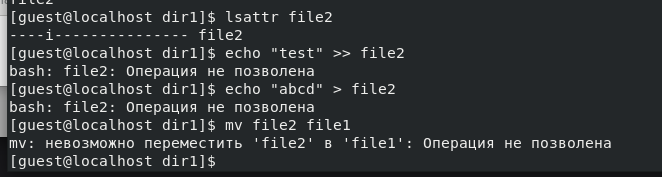

Попытка манипуляций с файлом сновым атрибутом

Как и в прошлый раз, попытки не увенчались успехом.

## Вывод

В результате выполнения работы мы повысили свои навыки использования интерфейса командой строки, познакомились на примерах с тем, как используются основные и расширенные атрибуты при разграничении доступа.

## Список литературы. Библиография

[0] Методические материалы курса

[1] Права доступа: https://codechick.io/tutorials/unix-linux/unix-linux-permissions

[2] Расширенные атрибуты: https://ru.manpages.org/xattr/7

[3] Операции с расширенными атрибутами: https://p-n-z-8-8.livejournal.com/64493.html

:::